# Temperatura JP x CG

### Qual foi o São João mais frio de CG que está nos nossos dados?

Considerando as temperaturas máximas por ano no mês de junho, vemos que ela ocorreu em 2004.

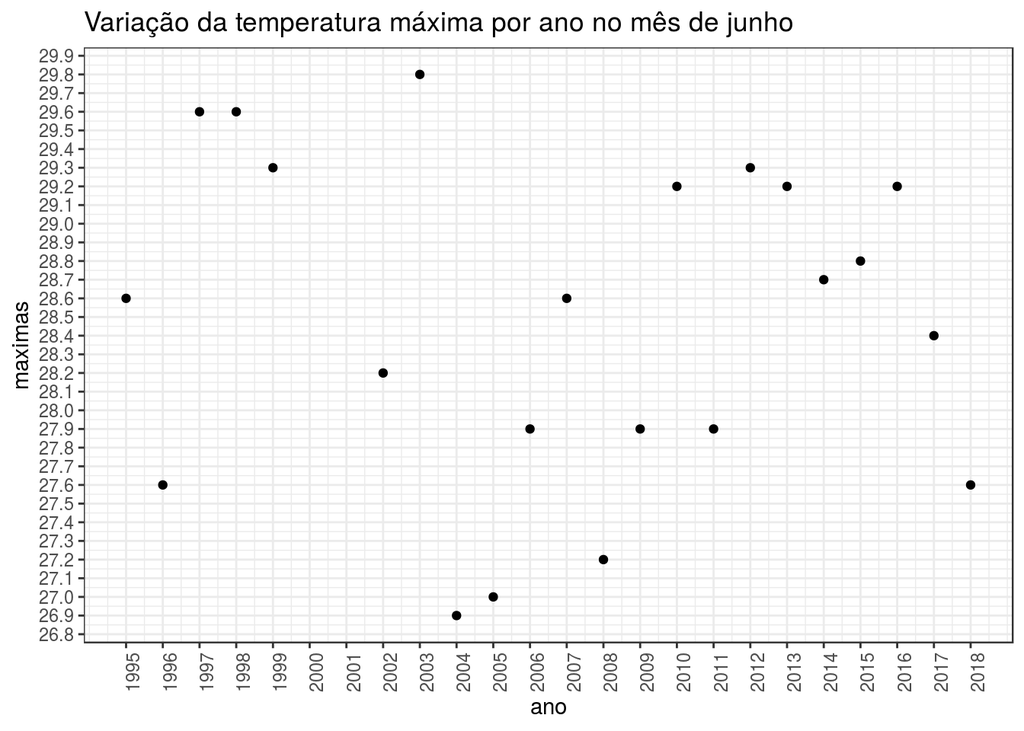

```r
cg_mais_frio_max <- filter(climas, cidade == "Campina Grande", mes == 6)
cg_mais_frio_max <- select(cg_mais_frio_max, tmax, semana, mes, ano, cidade)
cg_mais_frio_max <- group_by(cg_mais_frio_max, ano)
cg_mais_frio_max <- arrange(cg_mais_frio_max, ano)
cg_mais_frio_max <- summarise(cg_mais_frio_max, maximas = max(tmax))

  ggplot(data = cg_mais_frio_max, mapping = aes(x = ano, y = maximas)) +
  geom_point() +
  scale_x_continuous(breaks = seq(1995,2018,1)) +
  scale_y_continuous(breaks = seq(15,40,0.1)) +
  theme(axis.text.x = element_text(angle = 90)) +
  labs(title = "Variação da temperatura máxima por ano no mês de junho")
```

Considerando as temperaturas mínimas por ano no mês de junho, vemos que ela ocorreu em 2008.

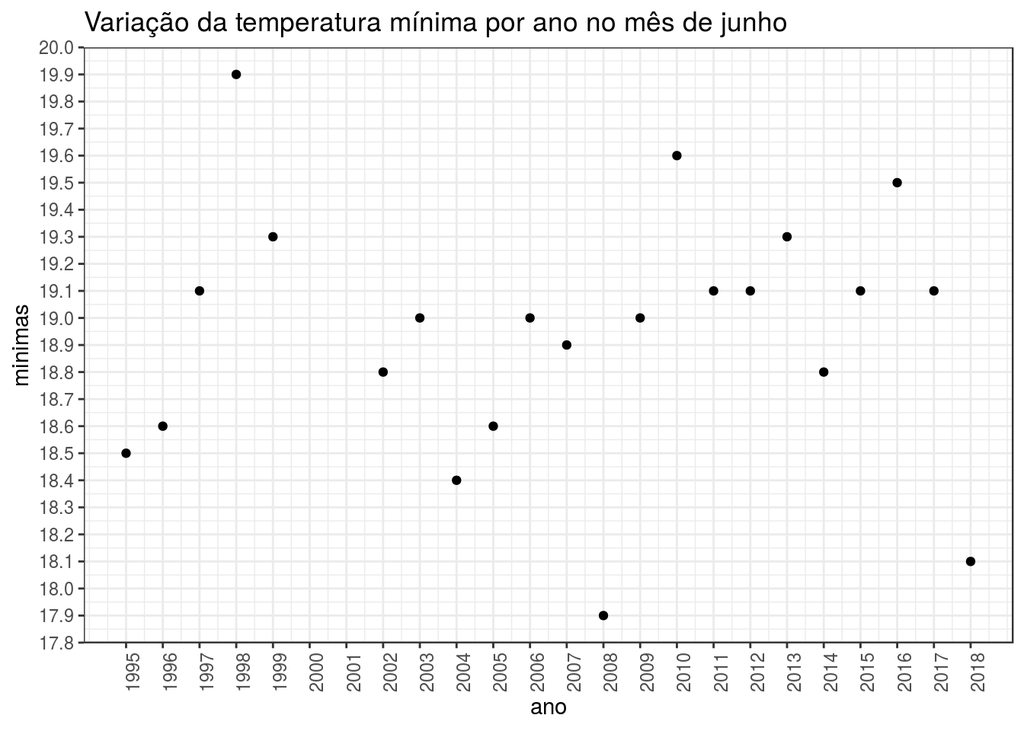

```r
cg_mais_frio_min <- filter(climas, cidade == "Campina Grande", mes == 6)
cg_mais_frio_min <- select(cg_mais_frio_min, tmin, semana, mes, ano, cidade)
cg_mais_frio_min <- group_by(cg_mais_frio_min, ano)
cg_mais_frio_min <- arrange(cg_mais_frio_min, ano)
cg_mais_frio_min <- summarise(cg_mais_frio_min, minimas = max(tmin))

  ggplot(data = cg_mais_frio_min, mapping = aes(x = ano, y = minimas)) +
  geom_point() +
  scale_x_continuous(breaks = seq(1995,2018,1)) +
  scale_y_continuous(breaks = seq(15,40,0.1)) +
  theme(axis.text.x = element_text(angle = 90)) +
  labs(title = "Variação da temperatura mínima por ano no mês de junho")
```

Considerando as temperaturas médias por ano no mês de junho, vemos que ela ocorreu em 2008.

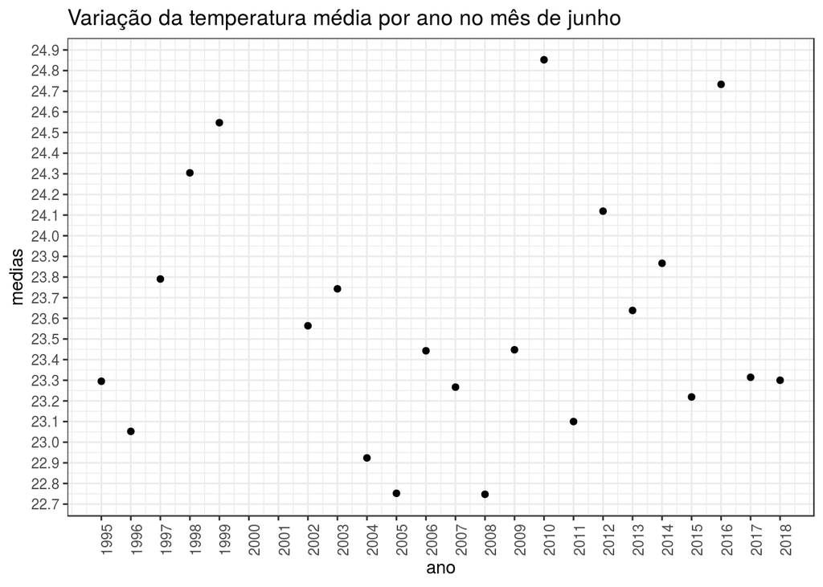

```r
cg_mais_frio_med <- filter(climas, cidade == "Campina Grande", mes == 6)
cg_mais_frio_med <- select(cg_mais_frio_med, tmedia, semana, mes, ano, cidade)
cg_mais_frio_med <- group_by(cg_mais_frio_med, ano)
cg_mais_frio_med <- arrange(cg_mais_frio_med, ano)
cg_mais_frio_med <- summarise(cg_mais_frio_med, medias = max(tmedia))

  ggplot(data = cg_mais_frio_med, mapping = aes(x = ano, y = medias)) +
  geom_point() +
#  geom_text(aes(label=medias),hjust=0, vjust=0) +
  scale_x_continuous(breaks = seq(1995,2018,1)) +
  scale_y_continuous(breaks = seq(15,40,0.1)) +
  theme(axis.text.x = element_text(angle = 90)) +
  labs(title = "Variação da temperatura média por ano no mês de junho")
```

Como ocorreu a menor temperatura mínima e a menor média em 2008, podemos considerar que o mês de São João mais frio ocorreu em 2008.